# ELE618 - Sistemas Elétricos Industriais

Instalações Elétricas - Ademaro A. M. B. Cotrim  
Capítulo 14

Prof. Dr. Thales A. C. Maia

UFMG - DEE

# Introdução

- Necessidade do controle preciso da operação das cargas.
- Considerações necessárias:
  - Comportamento da carga na instalação (variação e curva de carga).
  - Característica de não-linearidade da carga e seu conteúdo harmônico.
  - Possíveis fontes distintas alimentando as mesmas cargas.
  - Impacto da compensação reativa na instalação.
  - Regulamentação tarifária (cobrança de energia reativa excedente).
  - Impactos na eficiência energética, qualidade de energia e produtividade.

## Motivações para injeção de reativos

- Melhorar a regulação de tensão.
- Melhorar a eficiência de equipamentos.
- Reduzir as perdas e correntes elétricas.
- Faturamento de energia reativa (multas) imposto pelas concessionárias.
- Necessidade de adequação do fator de potência (limite atual de 92%).

# Aspectos conceituais

- **Energia ativa (P)**: convertida em energia útil (mecânica, calor). Medida em kW.
- **Energia reativa (Q)**: excitação magnética de equipamentos indutivos. Medida em kvar.
- **Potência aparente (S)**: produto das correntes e tensões eficazes. Medida em kVA.

## Cargas Lineares vs. Não-Lineares

- **Cargas Lineares**:
  - Corrente sem outras frequências além de 60 Hz.
  - O triângulo das potências se aplica.
- **Cargas Não-Lineares**:
  - Presença de harmônicas de corrente.
  - Potência aparente deve considerar componentes harmônicas.
  - Modelo do “Tetraedro das potências” incorpora a *potência de distorção* (D).
  - Fator de potência = $\frac{P}{S} = \cos(\theta) \cdot \cos(\delta)$.

# Causas do Baixo Fator de Potência

- Motores de indução operando em vazio ou sobrecarregados.
- Transformadores operando em vazio ou com pequenas cargas.
- Lâmpadas de descarga (reatores magnéticos).
- Grande quantidade de motores de pequena potência.
- Tensão acima da nominal.

# Compensação da Energia Reativa

- Princípio: injetar energia reativa para compensar a consumida pela carga.
- Capacitores (em paralelo) ou motores síncronos superexcitados.
- Em cargas lineares, busca-se reduzir o ângulo de fase.
- Em cargas não-lineares, a compensação deve considerar a variação da carga e componentes harmônicas.

## Métodos de Compensação

- **Aumento do consumo de energia ativa** (pouca aplicação).
- **Máquinas síncronas**: operando como “compensadores síncronos”.
- **Capacitores**: método mais comum, flexível e econômico.

## Localização dos Capacitores

- As vantagens relativas ao uso de capacitores apenas se aplicam à parte da instalação situada a montante de seu ponto de ligação.

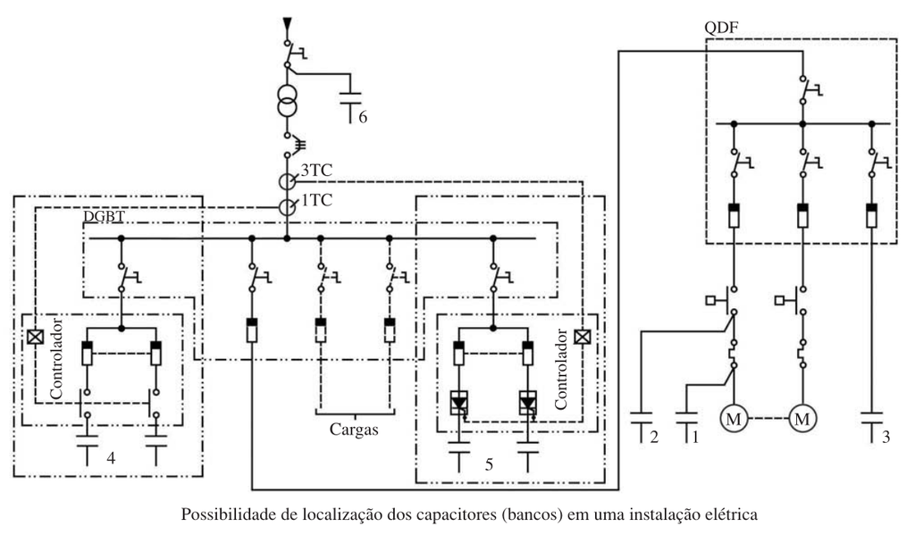

Fig. 1: Possibilidades de localização dos capacitores (bancos) em uma instalação elétrica (Cotrim, 2009)

- **Compensação individual**: Ligado diretamente aos bornes de ligação dos motores. A corrente do capacitor deve ser inferior à corrente de magnetização do motor.
- **Quadro de distribuição principal (global)**: Proporciona uma compensação global à instalação e libera carga no transformador, porém não reduz perdas nos diversos circuitos. Indicada para instalações mais simples.
- **Quadro de distribuição divisionário (intermediária)**: Indicada quando circuitos principais alimentam quadros com muitas cargas de pequeno porte.
- **Lado da média ou alta tensão**: Para grandes volumes de reativos.

## Tipos de Bancos de Capacitores

- **Banco fixo**: injeção fixa de energia reativa.
- **Banco semi-automático**: inseridos junto com a carga.
- **Banco automático**: manobrados em grupos por controlador.
- **Compensação estática (tempo real)**: resposta rápida (até 1 ciclo) para cargas extremamente variáveis.

# Aspectos da Carga e Ressonância

- **Ressonância Harmônica**: a indutância da rede e a capacitância formam um circuito ressonante.
- Ocorre quando a frequência de ressonância é próxima a uma corrente harmônica da carga.
- Consequências: amplificação de correntes, sobretensões, danos aos componentes.

## Prevenção de Ressonância

- Inserção de **reatores anti-ressonantes** em série com os capacitores.
- “Dessintonia” ajusta a impedância do conjunto.
- O sobredimensionamento da tensão dos capacitores é necessário nesses sistemas.

# Obrigado!

http://thalesmaia.com/